# Analisi di sensibilità

Author

Lorenzo Atzeni

## Sensitivity Analysis

In questa pagina sono presenti le **analisi di sensitività/robustezza** per verificare se le conclusioni del modello principale (m_level0=> tPTEF%tE ~ BPD × hsPDA ) **cambiano** quando modifichiamo la definizione delle esposizioni. In particolare: (i) sostituiamo BPD binaria con **BPD per severità** (no/mild/moderate/severe), e (ii) ricodifichiamo hsPDA da continuo a **categorie cliniche** (0, 1–7, >7) o a una forma **piecewise** (effetto 0–7 distinto dall’effetto oltre 7), così da testare l’ipotesi di una “critical window” e confrontare i modelli anche tramite **AIC**.

## 1) **BPD per severità** (no/mild/moderate/severe)

Vediamo come si distribuiscono i punteggi della severità di BPD:

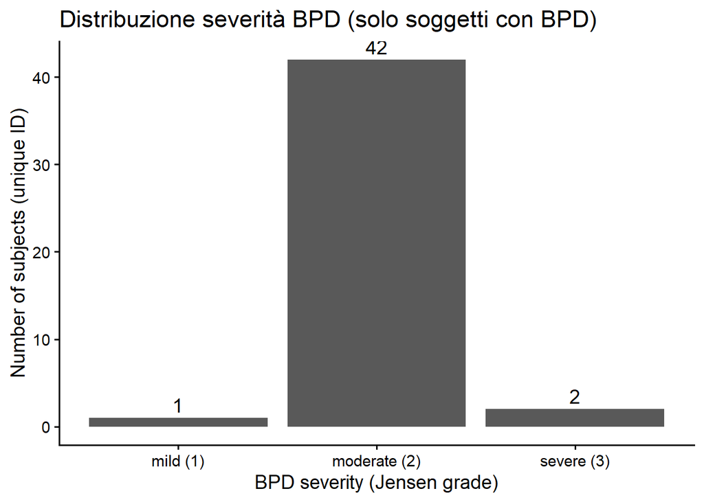

La categoria mild è scarsamente rappresentata (n=1), pertanto le stime specifiche per mild (in particolare le interazioni con hsPDA) non sono interpretabili; il modello viene usato solo come analisi esplorativa/sensitività. Si può fittare il modello ma ci saranno celle vuote/scarsamente popolate nelle combinazioni BPD_sev × hsPDA e ovviamente alcune interazioni non saranno stimabili (termini rimossi per rank-deficiency). Pertanto, il modello non consente inferenze affidabili specifiche per il livello mild.

Alternative migliori per un’eventuale pubblicazione potrebbero essere il collassare quindi unire mild + moderate e fare un modello solo con moderate+severe vs noBPD.

```
 Family: Gamma  ( log )
Formula:
tPTEF_perc_tE ~ Time + BPD_sev * hsPDA + GA + sex + LOS + PH +      (1 | ID)
Data: df_sens

      AIC       BIC    logLik -2*log(L)  df.resid
     1246      1292      -609      1218       183

Random effects:

Conditional model:
 Groups Name        Variance Std.Dev.
 ID     (Intercept) 0.04449  0.2109
Number of obs: 197, groups:  ID, 84

Dispersion estimate for Gamma family (sigma^2): 0.0578

Conditional model:
                       Estimate Std. Error z value Pr(>|z|)
(Intercept)            1.609844   0.547621   2.940  0.00329 **
Time                  -0.003128   0.003259  -0.960  0.33724
BPD_sevmild           -0.067622   0.342228  -0.198  0.84336
BPD_sevmoderate       -0.105006   0.087039  -1.206  0.22765
BPD_sevsevere         -0.077540   0.289144  -0.268  0.78857
hsPDA                 -0.006546   0.014738  -0.444  0.65694
GA                     0.050657   0.018667   2.714  0.00665 **
sex2                   0.150369   0.067717   2.221  0.02638 *
LOS1                   0.050767   0.070474   0.720  0.47130
PH1                   -0.203994   0.079054  -2.580  0.00987 **
BPD_sevmild:hsPDA            NA         NA      NA       NA
BPD_sevmoderate:hsPDA  0.006666   0.016384   0.407  0.68409
BPD_sevsevere:hsPDA   -0.220178   0.201861  -1.091  0.27539
---
Signif. codes:  0 '***' 0.001 '**' 0.01 '*' 0.05 '.' 0.1 ' ' 1
```

## 2) Categorico PDA: 0 / 1–7 / >7

Vediamo anche qui la frequenza:

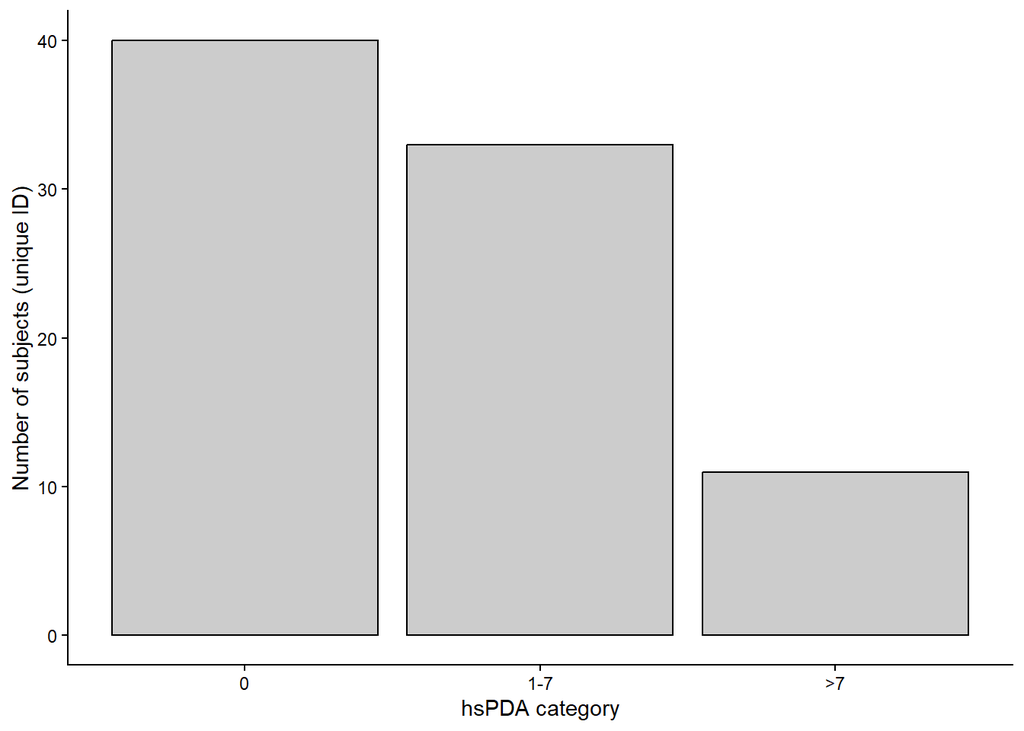

```r
df_pda_cat <- df_mod %>%
  mutate(
    hsPDA_cat = cut(hsPDA, breaks = c(-Inf, 0, 7, Inf),
                    labels = c("0", "1-7", ">7")),
    hsPDA_cat = relevel(hsPDA_cat, ref = "0")
  )

m_pda_cat <- glmmTMB(
  tPTEF_perc_tE ~ Time + BPD * hsPDA_cat + GA + sex + LOS + PH + (1 | ID),
  family = Gamma(link = "log"),
  data = df_pda_cat
)
summary(m_pda_cat)
```

```
 Family: Gamma  ( log )
Formula:
tPTEF_perc_tE ~ Time + BPD * hsPDA_cat + GA + sex + LOS + PH +      (1 | ID)
Data: df_pda_cat

      AIC       BIC    logLik -2*log(L)  df.resid
   1245.4    1288.0    -609.7    1219.4       184

Random effects:

Conditional model:
 Groups Name        Variance Std.Dev.
 ID     (Intercept) 0.04542  0.2131
Number of obs: 197, groups:  ID, 84

Dispersion estimate for Gamma family (sigma^2): 0.0579

Conditional model:
                   Estimate Std. Error z value Pr(>|z|)
(Intercept)        1.777310   0.573318   3.100  0.00193 **
Time              -0.003191   0.003241  -0.985  0.32484
BPD1              -0.131903   0.107231  -1.230  0.21867
hsPDA_cat1-7       0.014504   0.112318   0.129  0.89725
hsPDA_cat>7       -0.165148   0.192233  -0.859  0.39028
GA                 0.044899   0.019444   2.309  0.02094 *
sex2               0.157384   0.068327   2.303  0.02126 *
LOS1               0.024619   0.070892   0.347  0.72838
PH1               -0.214522   0.080705  -2.658  0.00786 **
BPD1:hsPDA_cat1-7  0.035613   0.145217   0.245  0.80627
BPD1:hsPDA_cat>7   0.139487   0.220515   0.633  0.52703
---
Signif. codes:  0 '***' 0.001 '**' 0.01 '*' 0.05 '.' 0.1 ' ' 1
```

## 3) Piecewise (0–7 e >7)

```r
df_piece <- df_mod %>%
  mutate(
    pda_0_7 = pmin(hsPDA, 7),
    pda_gt7 = pmax(hsPDA - 7, 0)
  )

m_piece <- glmmTMB(
  tPTEF_perc_tE ~ Time + BPD * (pda_0_7 + pda_gt7) + GA + sex + LOS + PH + (1 | ID),
  family = Gamma(link = "log"),
  data = df_piece
)

summary(m_piece)
```

```
 Family: Gamma  ( log )
Formula:
tPTEF_perc_tE ~ Time + BPD * (pda_0_7 + pda_gt7) + GA + sex +
    LOS + PH + (1 | ID)
Data: df_piece

      AIC       BIC    logLik -2*log(L)  df.resid
   1241.3    1283.9    -607.6    1215.3       184

Random effects:

Conditional model:
 Groups Name        Variance Std.Dev.
 ID     (Intercept) 0.04174  0.2043
Number of obs: 197, groups:  ID, 84

Dispersion estimate for Gamma family (sigma^2): 0.058

Conditional model:
              Estimate Std. Error z value Pr(>|z|)
(Intercept)   1.579002   0.530639   2.976  0.00292 **
Time         -0.003019   0.003229  -0.935  0.34971
BPD1         -0.149657   0.089623  -1.670  0.09495 .
pda_0_7       0.019791   0.027913   0.709  0.47830
pda_gt7      -0.053900   0.047053  -1.146  0.25200
GA            0.052430   0.018106   2.896  0.00378 **
sex2          0.146794   0.066688   2.201  0.02772 *
LOS1         -0.017905   0.071104  -0.252  0.80119
PH1          -0.211027   0.076228  -2.768  0.00563 **
BPD1:pda_0_7  0.011911   0.031040   0.384  0.70118
BPD1:pda_gt7  0.029589   0.049101   0.603  0.54676
---
Signif. codes:  0 '***' 0.001 '**' 0.01 '*' 0.05 '.' 0.1 ' ' 1
```

Confrontiamo i modelli:

```r
m_level0 <- readRDS(here("data", "derived", "m_level0.rds"))
AIC(m_level0, m_sev, m_pda_cat, m_piece)
```

```
          df      AIC
m_level0  11 1242.492
m_sev     14 1246.020
m_pda_cat 13 1245.354
m_piece   13 1241.264
```

```r
BIC(m_level0, m_sev, m_pda_cat, m_piece)
```

```
          df      BIC
m_level0  11 1278.607
m_sev     14 1291.985
m_pda_cat 13 1288.036
m_piece   13 1283.946
```

Nel complesso, le analisi di sensitività **non modificano in modo sostanziale le conclusioni** del modello principale.

← Torna indietro